# prediction_writeup

YingCai

2017-11-29

## Overview

This document is the final report of the Peer Assessment project from Coursera’s course Practical Machine Learning, as part of the Specialization in Data Science. It was built in RStudio, using its knitr functions, meant to be published in html format. This analysis meant to be the basis for the course quiz and a prediction assignment writeup. The main goal of the project is to predict the manner in which 6 participants performed some exercise as described below. This is the “classe” variable in the training set. The machine learning algorithm described here is applied to the 20 test cases available in the test data and the predictions are submitted in appropriate format to the Course Project Prediction Quiz for automated grading.

## Background

Using devices such as Jawbone Up, Nike FuelBand, and Fitbit it is now possible to collect a large amount of data about personal activity relatively inexpensively. These type of devices are part of the quantified self movement – a group of enthusiasts who take measurements about themselves regularly to improve their health, to find patterns in their behavior, or because they are tech geeks. One thing that people regularly do is quantify how much of a particular activity they do, but they rarely quantify how well they do it. In this project, your goal will be to use data from accelerometers on the belt, forearm, arm, and dumbell of 6 participants. They were asked to perform barbell lifts correctly and incorrectly in 5 different ways. More information is available from the website here: http://web.archive.org/web/20161224072740/http:/groupware.les.inf.puc-rio.br/har (see the section on the Weight Lifting Exercise Dataset).

## Data Loading & Exploratory Analysis

### 01-Download Data Files

```r
library(knitr)
library(caret)
```

```r
library(rpart)
library(rpart.plot)
library(rattle)
library(randomForest)
library(corrplot)
set.seed(213)

setwd("E:\\Coursera\\Pratical Machine Learning")

if (!file.exists("./data")) {
  dir.create("./data")
}
if (!file.exists("./data/pml-training.csv")) {
  url.training <- "https://d396qusza40orc.cloudfront.net/predmachlearn/pml-training.csv"
  download.file(url.training, destfile = "./data/pml-training.csv")
}

if (!file.exists("./data/pml-testing.csv")) {
  url.testing <- "https://d396qusza40orc.cloudfront.net/predmachlearn/pml-testing.csv"
  download.file(url.testing, destfile = "./data/pml-testing.csv")
}

training <- read.csv("./data/pml-training.csv")
testing <- read.csv("./data/pml-testing.csv")

# create data partition
inTrain  <- createDataPartition(training$classe, p=0.7, list=FALSE)

TrainSet <- training[inTrain, ]

TestSet  <- training[-inTrain, ]

dim(TrainSet)
```

```
## [1] 13737   160
```

```r
dim(TestSet)
```

```
## [1] 5885  160
```

### 02-Data Cleaning

Clean following variables:

- NA
- The Near Zero variance(NZV)
- ID variables

```r
#NA
AllNA    <- sapply(TrainSet, function(x) mean(is.na(x))) > 0.95
TrainSet <- TrainSet[, AllNA==FALSE]
TestSet  <- TestSet[, AllNA==FALSE]
#NZV
NZV <- nearZeroVar(TrainSet)
TrainSet <- TrainSet[, -NZV]
TestSet  <- TestSet[, -NZV]
#ID
TrainSet <- TrainSet[, -(1:5)]
TestSet  <- TestSet[, -(1:5)]
#Result
dim(TrainSet)
```

```
## [1] 13737    54
```

```r
dim(TestSet)
```

```
## [1] 5885   54
```

There are only 54 variables for analysis

### 03-Coorection Analysis

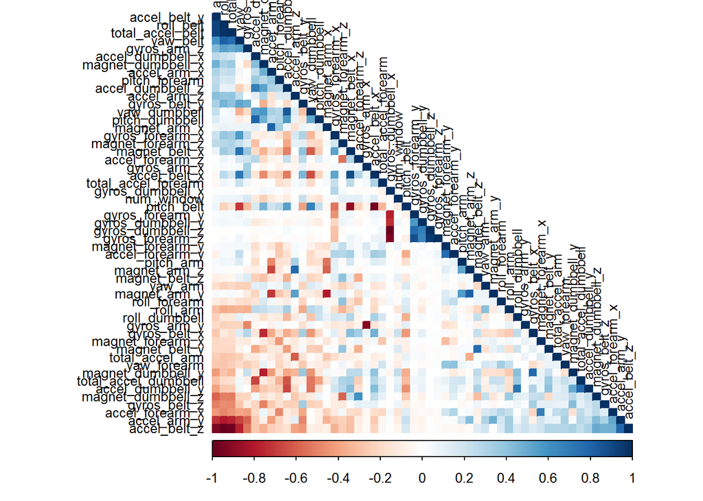

```r
corMatrix <- cor(TrainSet[, -54])
corrplot(corMatrix, order = "FPC", method = "color", type = "lower", tl.cex = 0.8, tl.col = rgb(0, 0, 0))
```

The highly correlated variables are shown in dark colors in the graph above. To make an even more compact analysis, a PCA (Principal Components Analysis) could be performed as pre-processing step to the datasets. Nevertheless, as the correlations are quite few, this step will not be applied for this assignment.

## Prediction Model Building

Three popular methods will be applied to model the regressions (in the Train dataset) and the best one (with higher accuracy when applied to the Test dataset) will be used for the quiz predictions. The methods are: Random Forests, Decision Tree and Generalized Boosted Model, as described below. A Confusion Matrix is plotted at the end of each analysis to better visualize the accuracy of the models.

### 01-Random Forests

```r
controlRF <- trainControl(method = "cv", number=3, verboseIter = FALSE)
modFitRandForest <- train(classe ~ ., data = TrainSet, method = "rf", trControl=controlRF)
modFitRandForest$finalModel
```

```
##
## Call:
##  randomForest(x = x, y = y, mtry = param$mtry)
##                Type of random forest: classification
##                      Number of trees: 500
## No. of variables tried at each split: 27
##
##         OOB estimate of  error rate: 0.21%
## Confusion matrix:
##      A    B    C    D    E  class.error
## A 3904    1    0    0    1 0.0005120328
## B    7 2649    2    0    0 0.0033860045
## C    0    6 2388    2    0 0.0033388982
## D    0    0    8 2244    0 0.0035523979
## E    0    0    0    2 2523 0.0007920792
```

```r
# prediction on Test set
predictRandForest <- predict(modFitRandForest, newdata=TestSet)
confMatRandForest <- confusionMatrix(predictRandForest,TestSet$classe)
confMatRandForest
```

```
## Confusion Matrix and Statistics
##
##           Reference
## Prediction    A    B    C    D    E
##          A 1674    2    0    0    0
##          B    0 1135    0    0    0
##          C    0    2 1026    2    0
##          D    0    0    0  961    4
##          E    0    0    0    1 1078
##
## Overall Statistics
##
##                Accuracy : 0.9981
##                  95% CI : (0.9967, 0.9991)
##     No Information Rate : 0.2845
##     P-Value [Acc > NIR] : < 2.2e-16
##
##                   Kappa : 0.9976
##  Mcnemar's Test P-Value : NA
##
## Statistics by Class:
##
##                      Class: A Class: B Class: C Class: D Class: E
## Sensitivity            1.0000   0.9965   1.0000   0.9969   0.9963
## Specificity            0.9995   1.0000   0.9992   0.9992   0.9998
## Pos Pred Value         0.9988   1.0000   0.9961   0.9959   0.9991
## Neg Pred Value         1.0000   0.9992   1.0000   0.9994   0.9992
## Prevalence             0.2845   0.1935   0.1743   0.1638   0.1839
## Detection Rate         0.2845   0.1929   0.1743   0.1633   0.1832
## Detection Prevalence   0.2848   0.1929   0.1750   0.1640   0.1833
## Balanced Accuracy      0.9998   0.9982   0.9996   0.9980   0.9980
```

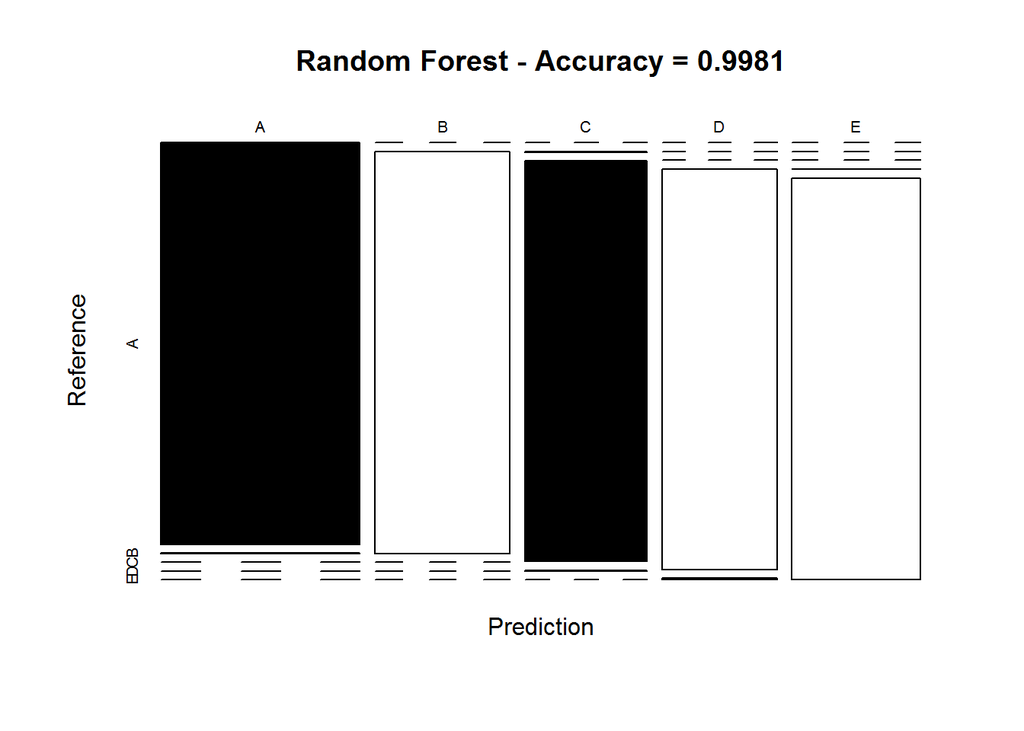

```r
# plot results for better understanding
plot(confMatRandForest$table, col = confMatRandForest$byClass,main = paste("Random Forest - Accuracy =",round(confMatRandForest$overall['Accuracy'], 4)))
```

### 02-Decision Tree

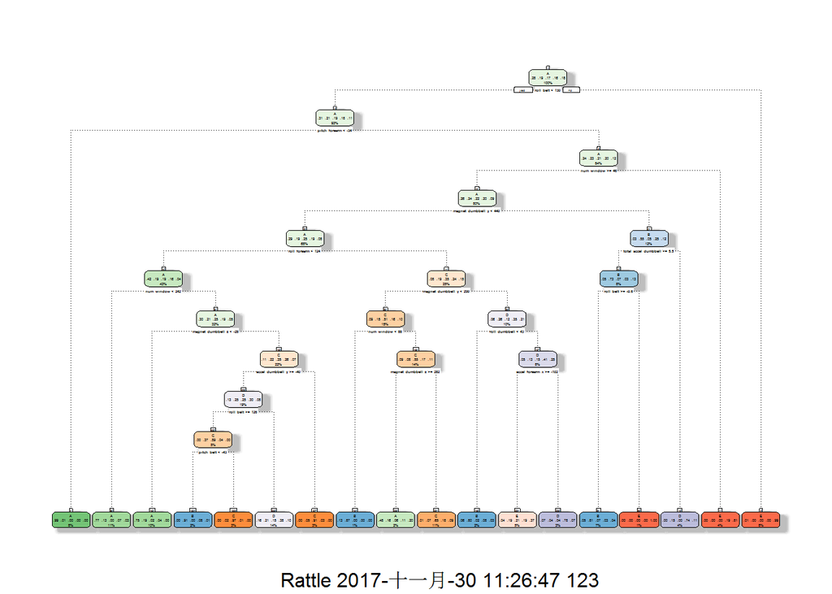

```r
modFitDecTree <- rpart(classe ~ ., data=TrainSet, method="class")
fancyRpartPlot(modFitDecTree)
```

```r
# prediction on Test set
predictDecTree <- predict(modFitDecTree, newdata=TestSet, type="class")
confMatDecTree <- confusionMatrix(predictDecTree, TestSet$classe)
confMatDecTree
```

```
## Confusion Matrix and Statistics
##
##           Reference
## Prediction    A    B    C    D    E
##          A 1435  194   18   76   53
##          B   49  575   33   24   26
##          C   10   63  780  130   74
##          D  158  244  133  640  125
##          E   22   63   62   94  804
##
## Overall Statistics
##
##                Accuracy : 0.7195
##                  95% CI : (0.7078, 0.7309)
##     No Information Rate : 0.2845
##     P-Value [Acc > NIR] : < 2.2e-16
##
##                   Kappa : 0.6452
##  Mcnemar's Test P-Value : < 2.2e-16
##
## Statistics by Class:
##
##                      Class: A Class: B Class: C Class: D Class: E
## Sensitivity            0.8572  0.50483   0.7602   0.6639   0.7431
## Specificity            0.9190  0.97219   0.9430   0.8659   0.9498
## Pos Pred Value         0.8080  0.81330   0.7379   0.4923   0.7694
## Neg Pred Value         0.9418  0.89108   0.9490   0.9293   0.9426
## Prevalence             0.2845  0.19354   0.1743   0.1638   0.1839
## Detection Rate         0.2438  0.09771   0.1325   0.1088   0.1366
## Detection Prevalence   0.3018  0.12014   0.1796   0.2209   0.1776
## Balanced Accuracy      0.8881  0.73851   0.8516   0.7649   0.8464
```

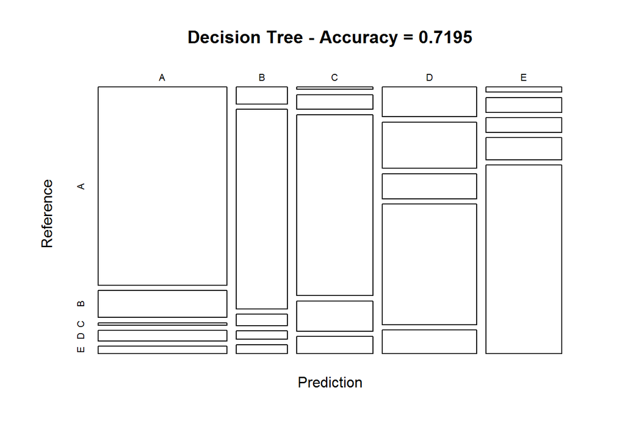

```r
# plot results for better understanding
plot(confMatDecTree$table, col = confMatDecTree$byClass, main = paste("Decision Tree - Accuracy =",round(confMatDecTree$overall['Accuracy'], 4)))
```

### 03-Generalized Boosted Model(GBM)

```r
controlGBM <- trainControl(method = "repeatedcv", number = 5, repeats = 1)
modFitGBM  <- train(classe ~ ., data=TrainSet, method = "gbm",trControl = controlGBM, verbose = FALSE)
# prediction on Test set
predictGBM <- predict(modFitGBM, newdata=TestSet)
confMatGBM <- confusionMatrix(predictGBM, TestSet$classe)
confMatGBM
```

```
## Confusion Matrix and Statistics
##
##           Reference
## Prediction    A    B    C    D    E
##          A 1672    3    0    1    0
##          B    2 1120   13    6    2
##          C    0   11 1010    7    2
##          D    0    5    2  950    8
##          E    0    0    1    0 1070
##
## Overall Statistics
##
##                Accuracy : 0.9893
##                  95% CI : (0.9863, 0.9918)
##     No Information Rate : 0.2845
##     P-Value [Acc > NIR] : < 2.2e-16
##
##                   Kappa : 0.9865
##  Mcnemar's Test P-Value : NA
##
## Statistics by Class:
##
##                      Class: A Class: B Class: C Class: D Class: E
## Sensitivity            0.9988   0.9833   0.9844   0.9855   0.9889
## Specificity            0.9991   0.9952   0.9959   0.9970   0.9998
## Pos Pred Value         0.9976   0.9799   0.9806   0.9845   0.9991
## Neg Pred Value         0.9995   0.9960   0.9967   0.9972   0.9975
## Prevalence             0.2845   0.1935   0.1743   0.1638   0.1839
## Detection Rate         0.2841   0.1903   0.1716   0.1614   0.1818
## Detection Prevalence   0.2848   0.1942   0.1750   0.1640   0.1820
## Balanced Accuracy      0.9989   0.9892   0.9901   0.9912   0.9944
```

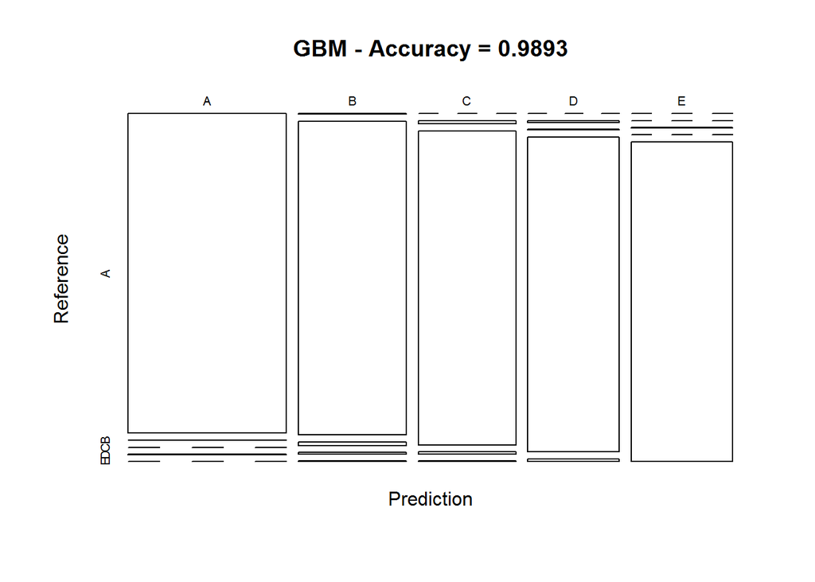

```r
# plot results for better understanding
plot(confMatGBM$table, col = confMatGBM$byClass,
     main = paste("GBM - Accuracy =", round(confMatGBM$overall['Accuracy'], 4)))
```

## Applying Model to the Test Set

Therefore, I use Random Forest model to apply prediction on test data.

```r
predictTEST <- predict(modFitRandForest, newdata=testing)
predictTEST
```

```
##  [1] B A B A A E D B A A B C B A E E A B B B
## Levels: A B C D E
```